# A thorough analysis between Michael Jordan and LeBron James

Charles Bangert, Noah Tanenholtz, Ryan Dietz

5/22/2019

## Final Project for CMSC320: Introduction to Data Science

# Summary

It is widley debated between basketball fans, sportscasters, and sports analysts on which NBA player is the greatest of all time. Some people say that it is Michael Jordan, while others say that is LeBron James. This markdown is a tutorial that will walk you through the entire data science pipeline and will provide you with a thorough analysis of data, leading to a determination on the which player is the greatest of all time. Our results will be discussed at the end.

We have provided some resources that may interest you on the popularity of this debate between MJ and LeBron and who is the better player.

One resource is from CBS Sports which surveyed 100 NCAA basketball coaches in the Fall of 2018 on who they belive is the better player. MJ recieved 82% of the vote while LeBron recieved 18% of the vote. Find out more here: https://www.cbssports.com/college-basketball/news/candid-coaches-whos-the-real-goat-michael-jordan-or-lebron-james/.

Another resource that may interest you is from USA Today: https://www.usatoday.com/story/sports/nba/2018/05/13/michael-jordan-lebron-james-which-one-greatest-all-time/602231002/. This resource also includes some ananlysis on in-game stats between the two players.

# Setting up the libraries

```r
library(tidyverse)
library(tidyr)
library(dplyr)
library("rvest")
library(reshape2)
library(SparkR)
```

# Getting the data

Data can be read in from CSV files using read_csv() and then stored into data frames with as.data.frame().

```r
csv <- read_csv("pergame_data.csv")
pergame <- csv %>% as.data.frame()
pergame
```

| Rk | Player | From | To | G | GS | MP | FG | FGA | FG% | 3P | 3PA | 3P% | 2P | 2PA | 2P% | eFG% | FT | FTA | FT% | ORB | DRB | TRB | AST | STL | BLK | TOV | PF | PTS |
| --- | --- | --- | --- | --- | --- | --- | --- | --- | --- | --- | --- | --- | --- | --- | --- | --- | --- | --- | --- | --- | --- | --- | --- | --- | --- | --- | --- | --- |
| 1 | LeBron James | 2004 | 2019 | 1198 | 1197 | 38.6 | 9.9 | 19.6 | 0.504 | 1.4 | 4.2 | 0.343 | 8.4 | 15.4 | 0.548 | 0.541 | 6.0 | 8.1 | 0.736 | 1.2 | 6.2 | 7.4 | 7.2 | 1.6 | 0.8 | 3.5 | 1.8 | 27.2 |
| 2 | Michael Jordan* | 1985 | 2003 | 1072 | 1039 | 38.3 | 11.4 | 22.9 | 0.497 | 0.5 | 1.7 | 0.327 | 10.8 | 21.2 | 0.510 | 0.509 | 6.8 | 8.2 | 0.835 | 1.6 | 4.7 | 6.2 | 5.3 | 2.3 | 0.8 | 2.7 | 2.6 | 30.1 |

```r
csv <- read_csv("totals_data.csv")
totals <- csv %>% as.data.frame()
totals
```

| Rk | Player | From | To | G | GS | MP | FG | FGA | FG% | 3P | 3PA | 3P% | 2P | 2PA | 2P% | eFG% | FT | FTA | FT% | ORB | DRB | TRB | AST | STL | BLK | TOV | PF | PTS |
| --- | --- | --- | --- | --- | --- | --- | --- | --- | --- | --- | --- | --- | --- | --- | --- | --- | --- | --- | --- | --- | --- | --- | --- | --- | --- | --- | --- | --- |
| 1 | LeBron James | 2004 | 2019 | 1198 | 1197 | 46235 | 11838 | 23478 | 0.504 | 1727 | 5028 | 0.343 | 10111 | 18450 | 0.548 | 0.541 | 7140 | 9701 | 0.736 | 1443 | 7437 | 8880 | 8662 | 1937 | 921 | 4163 | 2207 | 32543 |
| 2 | Michael Jordan* | 1985 | 2003 | 1072 | 1039 | 41011 | 12192 | 24537 | 0.497 | 581 | 1778 | 0.327 | 11611 | 22759 | 0.510 | 0.509 | 7327 | 8772 | 0.835 | 1668 | 5004 | 6672 | 5633 | 2514 | 893 | 2924 | 2783 | 32292 |

```r
csv <- read_csv("per36min.csv")
per36min <- csv %>% as.data.frame()
per36min
```

| Rk | Player | From | To | G | GS | MP | FG | FGA | FG% | 3P | 3PA | 3P% | 2P | 2PA | 2P% | FT | FTA | FT% | ORB | DRB | TRB | AST | STL | BLK | TOV | PF | PTS |
| --- | --- | --- | --- | --- | --- | --- | --- | --- | --- | --- | --- | --- | --- | --- | --- | --- | --- | --- | --- | --- | --- | --- | --- | --- | --- | --- | --- |
| 1 | LeBron James | 2004 | 2019 | 1198 | 1197 | 46235 | 9.2 | 18.3 | 0.504 | 1.3 | 3.9 | 0.343 | 7.9 | 14.4 | 0.548 | 5.6 | 7.6 | 0.736 | 1.1 | 5.8 | 6.9 | 6.7 | 1.5 | 0.7 | 3.2 | 1.7 | 25.3 |
| 2 | Michael Jordan* | 1985 | 2003 | 1072 | 1039 | 41011 | 10.7 | 21.5 | 0.497 | 0.5 | 1.6 | 0.327 | 10.2 | 20.0 | 0.510 | 6.4 | 7.7 | 0.835 | 1.5 | 4.4 | 5.9 | 4.9 | 2.2 | 0.8 | 2.6 | 2.4 | 28.3 |

```r
csv <- read_csv("per100poss.csv")
per100poss <- csv %>% as.data.frame()
per100poss
```

| Rk | Player | From | To | G | GS | MP | FG | FGA | FG% | 3P | 3PA | 3P% | 2P | 2PA | 2P% | FT | FTA | FT% | ORB | DRB | TRB | AST | STL | BLK | TOV | PF | PTS | X29 | ORtg | … |
| --- | --- | --- | --- | --- | --- | --- | --- | --- | --- | --- | --- | --- | --- | --- | --- | --- | --- | --- | --- | --- | --- | --- | --- | --- | --- | --- | --- | --- | --- | --- |
| 1 | LeBron James | 2004 | 2019 | 1198 | 1197 | 46235 | 13.3 | 26.5 | 0.504 | 1.9 | 5.7 | 0.343 | 11.4 | 20.8 | 0.548 | 8.0 | 10.9 | 0.736 | 1.6 | 8.4 | 10.0 | 9.8 | 2.2 | 1.0 | 4.7 | 2.5 | 36.7 | NA | 116 | … |
| 2 | Michael Jordan* | 1985 | 2003 | 1072 | 1039 | 41011 | 15.3 | 30.7 | 0.497 | 0.7 | 2.2 | 0.327 | 14.5 | 28.5 | 0.510 | 9.2 | 11.0 | 0.835 | 2.1 | 6.3 | 8.3 | 7.0 | 3.1 | 1.1 | 3.7 | 3.5 | 40.4 | NA | 118 | … |

```r
csv <- read_csv("advanced.csv")
advanced <- csv %>% as.data.frame()
advanced
```

| Rk | Player | From | To | G | MP | PER | TS% | 3PAr | FTr | ORB% | DRB% | TRB% | AST% | STL% | BLK% | TOV% | USG% | X19 | OWS | DWS | WS | WS/48 | X24 | OBPM | DBPM | BPM | VORP |
| --- | --- | --- | --- | --- | --- | --- | --- | --- | --- | --- | --- | --- | --- | --- | --- | --- | --- | --- | --- | --- | --- | --- | --- | --- | --- | --- | --- |
| 1 | LeBron James | 2004 | 2019 | 1198 | 46235 | 27.6 | 0.586 | 0.214 | 0.413 | 3.7 | 18.3 | 11.2 | 35.8 | 2.2 | 1.6 | 13.0 | 31.5 | NA | 159.6 | 67.0 | 226.6 | 0.235 | NA | 7.3 | 1.9 | 9.1 | 129.8 |
| 2 | Michael Jordan* | 1985 | 2003 | 1072 | 41011 | 27.9 | 0.569 | 0.072 | 0.358 | 4.7 | 14.1 | 9.4 | 24.9 | 3.1 | 1.4 | 9.3 | 33.3 | NA | 149.9 | 64.1 | 214.0 | 0.250 | NA | 7.0 | 1.1 | 8.1 | 104.4 |

# Basic Operations and tidying data

To make the data column names more recognizable of what they mean, we are going to use some basic R operations to change the column names and even delete columns as a whole.

Below is a way of changing column names is very easy and useful if you are going to change all of the column names. You must change the names in the order that they appear in the data frame.

```r
names(pergame) <- c("rank", "player", "year_from", "year_to", "games_played", "games_stared", "min_played", "fg_made", "fg_attempt", "fg_percent", "3p_made", "3p_attempt", "3p_percent", "2p_made", "2p_attempt", "2p_percent", "eff_fg_percent", "ft_made", "ft_att", "ft_percent", "off_rebounds", "def_rebounds", "total_rebounds", "assists", "steals", "blocks", "turnovers", "fouls", "points")
pergame
```

| rank | player | year_from | year_to | games_played | games_stared | min_played | fg_made | fg_attempt | fg_percent | 3p_made | 3p_attempt | 3p_percent | 2p_made | 2p_attempt | 2p_percent | eff_fg_percent | ft_made | ft_att | ft_percent | off_rebounds | def_rebounds | total_rebounds | assists | steals | blocks | turnovers | fouls | points |
| --- | --- | --- | --- | --- | --- | --- | --- | --- | --- | --- | --- | --- | --- | --- | --- | --- | --- | --- | --- | --- | --- | --- | --- | --- | --- | --- | --- | --- |
| 1 | LeBron James | 2004 | 2019 | 1198 | 1197 | 38.6 | 9.9 | 19.6 | 0.504 | 1.4 | 4.2 | 0.343 | 8.4 | 15.4 | 0.548 | 0.541 | 6.0 | 8.1 | 0.736 | 1.2 | 6.2 | 7.4 | 7.2 | 1.6 | 0.8 | 3.5 | 1.8 | 27.2 |
| 2 | Michael Jordan* | 1985 | 2003 | 1072 | 1039 | 38.3 | 11.4 | 22.9 | 0.497 | 0.5 | 1.7 | 0.327 | 10.8 | 21.2 | 0.510 | 0.509 | 6.8 | 8.2 | 0.835 | 1.6 | 4.7 | 6.2 | 5.3 | 2.3 | 0.8 | 2.7 | 2.6 | 30.1 |

Below is another way to change column names and is better to use when changing a few column names. You can change the column names in any order. However, it is a very repetive and unefficient way to change column names if you are changing all the names as shown above.

```r
colnames(totals)[colnames(totals) == "Rk"] <- "rank"
colnames(totals)[colnames(totals) == "Player"] <- "player"
colnames(totals)[colnames(totals) == "From"] <- "year_from"
colnames(totals)[colnames(totals) == "To"] <- "year_to"
colnames(totals)[colnames(totals) == "G"] <- "games_played"
colnames(totals)[colnames(totals) == "GS"] <- "games_started"
colnames(totals)[colnames(totals) == "MP"] <- "min_played"
colnames(totals)[colnames(totals) == "FG"] <- "fg_made"
colnames(totals)[colnames(totals) == "FGA"] <- "fg_attempt"
colnames(totals)[colnames(totals) == "FG."] <- "fg_percent"
colnames(totals)[colnames(totals) == "X3P"] <- "3p_made"
colnames(totals)[colnames(totals) == "X3PA"] <- "3p_attempt"
colnames(totals)[colnames(totals) == "X3P."] <- "3p_percent"
colnames(totals)[colnames(totals) == "X2P"] <- "2p_made"
colnames(totals)[colnames(totals) == "X2PA"] <- "2p_attempt"
colnames(totals)[colnames(totals) == "X2P."] <- "2p_percent"
colnames(totals)[colnames(totals) == "eFG."] <- "eff_fg_percent"
colnames(totals)[colnames(totals) == "FT"] <- "ft_made"
colnames(totals)[colnames(totals) == "FTA"] <- "ft_attempt"
colnames(totals)[colnames(totals) == "FT."] <- "ft_percent"
colnames(totals)[colnames(totals) == "ORB"] <- "off_rebounds"
colnames(totals)[colnames(totals) == "DRB"] <- "def_rebounds"
colnames(totals)[colnames(totals) == "TRB"] <- "total_rebounds"
colnames(totals)[colnames(totals) == "AST"] <- "assists"
colnames(totals)[colnames(totals) == "STL"] <- "steals"
colnames(totals)[colnames(totals) == "BLK"] <- "blocks"
colnames(totals)[colnames(totals) == "TOV"] <- "turnovers"
colnames(totals)[colnames(totals) == "PF"] <- "fouls"
colnames(totals)[colnames(totals) == "POints"] <- "points"

totals
```

| rank | player | year_from | year_to | games_played | games_started | min_played | fg_made | fg_attempt | FG% | 3P | 3PA | 3P% | 2P | 2PA | 2P% | eFG% | ft_made | ft_attempt | FT% | off_rebounds | def_rebounds | total_rebounds | assists | steals | blocks | turnovers | fouls | PTS |
| --- | --- | --- | --- | --- | --- | --- | --- | --- | --- | --- | --- | --- | --- | --- | --- | --- | --- | --- | --- | --- | --- | --- | --- | --- | --- | --- | --- | --- |
| 1 | LeBron James | 2004 | 2019 | 1198 | 1197 | 46235 | 11838 | 23478 | 0.504 | 1727 | 5028 | 0.343 | 10111 | 18450 | 0.548 | 0.541 | 7140 | 9701 | 0.736 | 1443 | 7437 | 8880 | 8662 | 1937 | 921 | 4163 | 2207 | 32543 |
| 2 | Michael Jordan* | 1985 | 2003 | 1072 | 1039 | 41011 | 12192 | 24537 | 0.497 | 581 | 1778 | 0.327 | 11611 | 22759 | 0.510 | 0.509 | 7327 | 8772 | 0.835 | 1668 | 5004 | 6672 | 5633 | 2514 | 893 | 2924 | 2783 | 32292 |

##### If you looked over all the data that was read in, in the previous step, then you should of noticed a blank column in the dataset of per100poss and advanced. We are going to show the steps needed to delete the blank columns and then change the column names for the two datasets.

```r
names(per36min) <- c("rank", "player", "year_from", "year_to", "games_played", "games_stared", "min_played", "fg_made", "fg_attempt", "fg_percent", "3p_made", "3p_attempt", "3p_percent", "2p_made", "2p_attempt", "2p_percent", "ft_made", "ft_att", "ft_percent", "off_rebounds", "def_rebounds", "total_rebounds", "assists", "steals", "blocks", "turnovers", "fouls", "points")
per36min
```

| rank | player | year_from | year_to | games_played | games_stared | min_played | fg_made | fg_attempt | fg_percent | 3p_made | 3p_attempt | 3p_percent | 2p_made | 2p_attempt | 2p_percent | ft_made | ft_att | ft_percent | off_rebounds | def_rebounds | total_rebounds | assists | steals | blocks | turnovers | fouls | points |
| --- | --- | --- | --- | --- | --- | --- | --- | --- | --- | --- | --- | --- | --- | --- | --- | --- | --- | --- | --- | --- | --- | --- | --- | --- | --- | --- | --- |
| 1 | LeBron James | 2004 | 2019 | 1198 | 1197 | 46235 | 9.2 | 18.3 | 0.504 | 1.3 | 3.9 | 0.343 | 7.9 | 14.4 | 0.548 | 5.6 | 7.6 | 0.736 | 1.1 | 5.8 | 6.9 | 6.7 | 1.5 | 0.7 | 3.2 | 1.7 | 25.3 |
| 2 | Michael Jordan* | 1985 | 2003 | 1072 | 1039 | 41011 | 10.7 | 21.5 | 0.497 | 0.5 | 1.6 | 0.327 | 10.2 | 20.0 | 0.510 | 6.4 | 7.7 | 0.835 | 1.5 | 4.4 | 5.9 | 4.9 | 2.2 | 0.8 | 2.6 | 2.4 | 28.3 |

We see that there is an error column in the per100poss data table named X29, you are going to need to know the column name to delete it. To delete the column, we set the error column to NULL.

```r
per100poss$X29 <- NULL

names(per100poss) <- c("rank", "player", "year_from", "year_to", "games_played", "games_stared", "min_played", "fg_made", "fg_attempt", "fg_percent", "3p_made", "3p_attempt", "3p_percent", "2p_made", "2p_attempt", "2p_percent", "ft_made", "ft_att", "ft_percent", "off_rebounds", "def_rebounds", "total_rebounds", "assists", "steals", "blocks", "turnovers", "fouls", "points", "off_rating", "def_rating")
per100poss
```

| rank | player | year_from | year_to | games_played | games_stared | min_played | fg_made | fg_attempt | fg_percent | 3p_made | 3p_attempt | 3p_percent | 2p_made | 2p_attempt | 2p_percent | ft_made | ft_att | ft_percent | off_rebounds | def_rebounds | total_rebounds | assists | steals | blocks | turnovers | fouls | points | off_rating | def_rating |
| --- | --- | --- | --- | --- | --- | --- | --- | --- | --- | --- | --- | --- | --- | --- | --- | --- | --- | --- | --- | --- | --- | --- | --- | --- | --- | --- | --- | --- | --- |
| 1 | LeBron James | 2004 | 2019 | 1198 | 1197 | 46235 | 13.3 | 26.5 | 0.504 | 1.9 | 5.7 | 0.343 | 11.4 | 20.8 | 0.548 | 8.0 | 10.9 | 0.736 | 1.6 | 8.4 | 10.0 | 9.8 | 2.2 | 1.0 | 4.7 | 2.5 | 36.7 | 116 | 103 |
| 2 | Michael Jordan* | 1985 | 2003 | 1072 | 1039 | 41011 | 15.3 | 30.7 | 0.497 | 0.7 | 2.2 | 0.327 | 14.5 | 28.5 | 0.510 | 9.2 | 11.0 | 0.835 | 2.1 | 6.3 | 8.3 | 7.0 | 3.1 | 1.1 | 3.7 | 3.5 | 40.4 | 118 | 103 |

We can also see that there are error columns in advanced data table named X19 and X24. You should also delete these columns by setting them to NULL.

```r
advanced$X19 <- NULL
advanced$X24 <- NULL

names(advanced) <- c("rank", "player", "year_from", "year_to", "games_played", "min_played", "eff_rating", "true_shooting_percent", "3p_attempt_rate", "ft_attempt_rate", "off_rebound_percent", "def_rebound_percent", "total_rebound_percent", "assist_percent", "steal_percent", "block_percent", "turnover_percent", "usage_percent", "off_win_share", "def_win_share", "win_share", "ws_per48min", "off_plus_minus", "def_plus_minus", "plus_minus", "value_over_replace")
advanced
```

| rank | player | year_from | year_to | games_played | min_played | eff_rating | true_shooting_percent | 3p_attempt_rate | ft_attempt_rate | off_rebound_percent | def_rebound_percent | total_rebound_percent | assist_percent | steal_percent | block_percent | turnover_percent | usage_percent | off_win_share | def_win_share | win_share | ws_per48min | off_plus_minus | def_plus_minus | plus_minus | value_over_replace |
| --- | --- | --- | --- | --- | --- | --- | --- | --- | --- | --- | --- | --- | --- | --- | --- | --- | --- | --- | --- | --- | --- | --- | --- | --- | --- |
| 1 | LeBron James | 2004 | 2019 | 1198 | 46235 | 27.6 | 0.586 | 0.214 | 0.413 | 3.7 | 18.3 | 11.2 | 35.8 | 2.2 | 1.6 | 13.0 | 31.5 | 159.6 | 67.0 | 226.6 | 0.235 | 7.3 | 1.9 | 9.1 | 129.8 |
| 2 | Michael Jordan* | 1985 | 2003 | 1072 | 41011 | 27.9 | 0.569 | 0.072 | 0.358 | 4.7 | 14.1 | 9.4 | 24.9 | 3.1 | 1.4 | 9.3 | 33.3 | 149.9 | 64.1 | 214.0 | 0.250 | 7.0 | 1.1 | 8.1 | 104.4 |

# Visualization

Creating plots is a great way to help readers visualize the data. Here’s a simple plot displaying field goals made per 36 minutes of playing time:

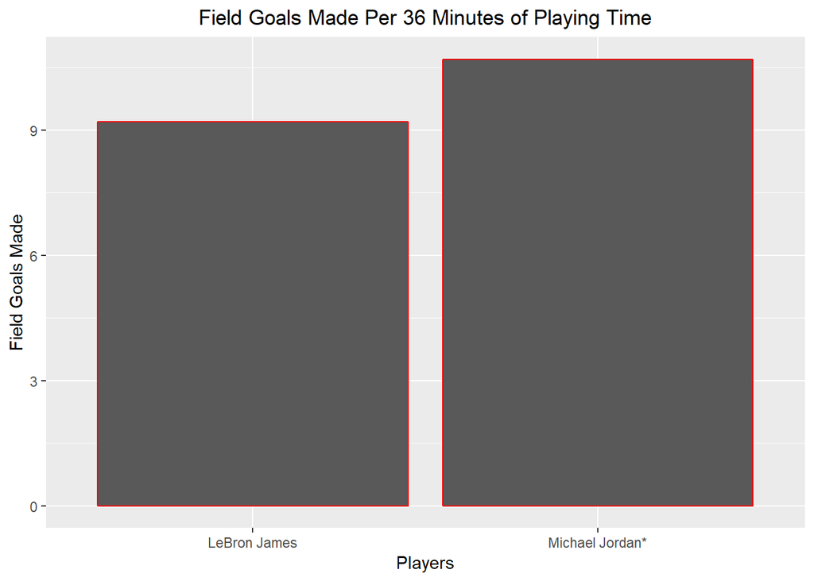

```r
per36min %>%
  ggplot(aes(x = player, y = fg_made)) +
  geom_bar(stat = "identity", color = "red") +
  labs(title = "Field Goals Made Per 36 Minutes of Playing Time", x = "Players", y = "Field Goals Made") +
  theme(plot.title = element_text(hjust = 0.5))
```

Looks good for MJ here.

Here’s another plot comparing the two, but we’re going to make a comparison of more then one stat all in one plot.

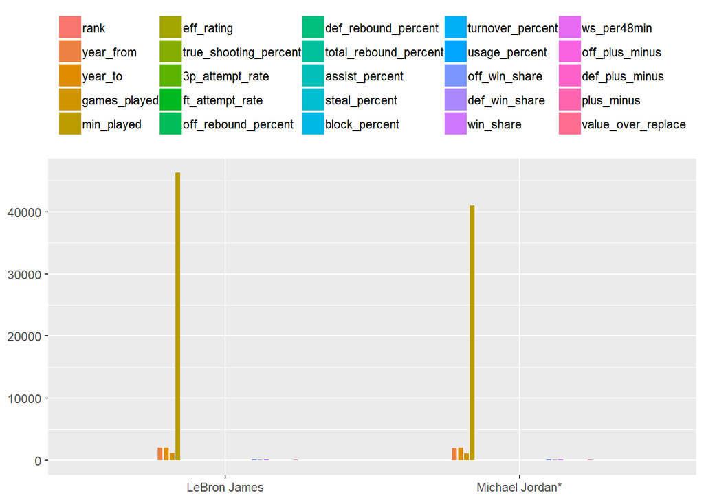

```r
advanced_prepped <- melt(advanced, id.vars='player')
 ggplot(advanced_prepped, aes(player, value)) + geom_bar(aes(fill = variable),
   width = 0.4, position = position_dodge(width=0.5), stat="identity") +
   theme(legend.position="top", legend.title =
   element_blank(),axis.title.x=element_blank(), axis.title.y=element_blank())
```

Notice the minutes_played, games_played, year_from and year_to statistics have numbers that are way higher than the other statistics, so it throws the scale off. Also, the rank column is irrelevant. We can filter that out to get a better-looking plot:

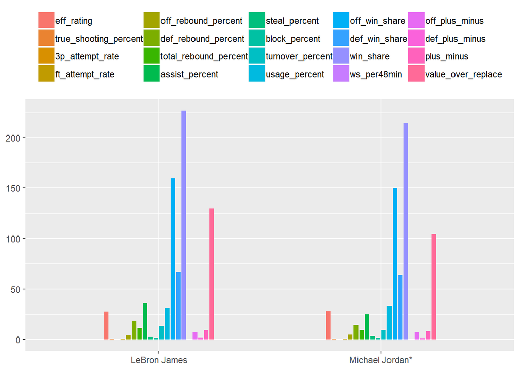

```r
advanced_prepped<- within(advanced, rm("min_played", "year_from", "year_to", "games_played","rank"))
advanced_prepped <- melt(advanced_prepped, id.vars=c("player") )
ggplot(advanced_prepped, aes(player, value)) + geom_bar(aes(fill = variable),
   width = 0.4, position = position_dodge(width=0.5), stat="identity") +
   theme(legend.position="top", legend.title =
   element_blank(),axis.title.x=element_blank(), axis.title.y=element_blank())
```

Beautiful.

A good way to compare players is by efficiency rating, which is calculated by the following formula (notice the embedded LATEX):
$$\frac{(Points + Rebounds + Assists + Steals + Blocks + MissedFieldGoals + MissedFreeThrows - Turnovers)} {GamesPlayed}$$

As we can see from the data, Lebron and Jordan are very close in these ratings: Jordan’s efficiency rating is 27.9, and Lebron’s is only slightly lower. This is illustrated in the following bar plot:

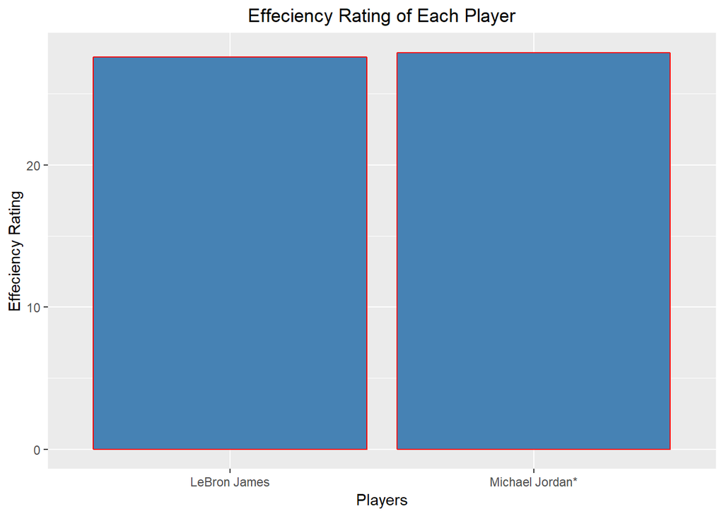

```r
advanced %>%
  ggplot(aes(x=player, y = eff_rating)) +
  geom_bar(stat = "identity", color = "red", fill = "steelblue") +
  labs(title="Effeciency Rating of Each Player", x="Players", y="Effeciency Rating") +
  theme(plot.title = element_text(hjust = 0.5))
```

As you can see from the plot, you can barely notice any difference between the two. Further hypothesis testing is required to see if this difference is signnificant. To be able to get some context to do this, we have to pull in more data on the efficiency rating of compaerable players. To do this, we’re going to scrape data from basketball-reference.com using the rvest package.

```r
url <- "https://www.basketball-reference.com/leaders/per_career.html#nba::none"

best_players_raw <- url %>%
  read_html() %>%
  html_nodes("table") %>% .[1] %>%
  html_table()
best_players <- best_players_raw %>% as.data.frame()
#rename the "PER" column to better indicate what it stands for
names(best_players)[3] <-  "Efficiency Rating"
best_players
```

| Rank | Player | Efficiency Rating |
| --- | --- | --- |
| 1 | Michael Jordan* | 27.91 |
| 2 | LeBron James | 27.59 |
| 3 | Anthony Davis | 27.42 |
| 4 | Shaquille O'Neal* | 26.43 |
| 5 | David Robinson* | 26.18 |
| 6 | Wilt Chamberlain* | 26.13 |
| 7 | Bob Pettit* | 25.35 |
| 8 | Chris Paul | 25.31 |
| 9 | Kevin Durant | 25.20 |
| 10 | Neil Johnston* | 24.69 |

[output cut: 240 more lines]

An asterisk next to a player’s name indicates that they are a hall of famer. Because we now have a much larger dataset it is a good idea to add a logical column to the data frame that will indicate whether a player is a hall of famer or not. You should also remove the asterisk next to each player that has one. This is shown below:

```r
best_players["Hall Of Famer"] <- ifelse(grepl("\\S+\\s\\S+\\*", best_players$Player), TRUE, FALSE)
best_players <- best_players %>%
  mutate_at(vars(Player), funs(str_replace(., "\\*", "")))
best_players
```

| Rank | Player | Efficiency Rating | Hall Of Famer |
| --- | --- | --- | --- |
| 1 | Michael Jordan | 27.91 | TRUE |
| 2 | LeBron James | 27.59 | FALSE |
| 3 | Anthony Davis | 27.42 | FALSE |
| 4 | Shaquille O'Neal | 26.43 | TRUE |
| 5 | David Robinson | 26.18 | TRUE |
| 6 | Wilt Chamberlain | 26.13 | TRUE |
| 7 | Bob Pettit | 25.35 | TRUE |
| 8 | Chris Paul | 25.31 | FALSE |
| 9 | Kevin Durant | 25.20 | FALSE |
| 10 | Neil Johnston | 24.69 | TRUE |

[output cut: 240 more lines]

Now, we have data on the efficiency ratings of the best 250 NBA players in history (best in regard to this statistic). Lets look at a plot to try and get a visualization of how they compare to each other.

Notice that we remove the x-axis labels with element_blank, as there are just too many names to fit in that small space. The names aren’t important here, we just want to show variation between players. I also ordered the bars of the plot to show how much better the top players are compared to the rest. You can also more clearly see the difference between MJ and Lebron’s rating (the tallest two bars)

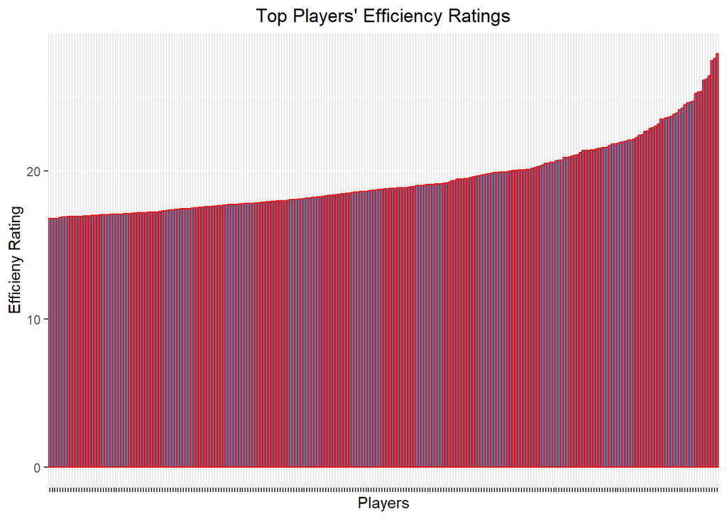

```r
best_players %>%
  ggplot(aes(x=reorder(Player, `Efficiency Rating`), y = `Efficiency Rating`)) +
  geom_bar(stat = "identity", color = "red", fill = "steelblue") +
  theme(axis.text.x = element_blank(), plot.title = element_text(hjust = .5)) +
  ggtitle("Top Players' Efficiency Ratings")+ xlab("Players") + ylab("Efficieny Rating")
```

From that plot we can see that there is some variation amongnst the top players. The two tallest bars are MJ and Lebron.

# Hypothesis Testing

So, to see if there is a statistically significant difference between Michael Jordan and Lebron James’ player efficiency ratings, we need to show some hypothesis testing.

Null Hypothesis: Michael Jordan’s Player Efficiency Rating being higher than Lebron’s is likely due to random variation.

The following code calculates the mean and standard deviation, then plots the Cumulative disribution function(cdf) and the probability density function(pdf).

First, get the mean of the efficiency rating across all players.

```r
avg <- mean(best_players$`Efficiency Rating`)
val <- best_players$`Efficiency Rating`
```

Now, we get the standard deviation.

```r
std <- sqrt(mean(val^2) - mean(best_players$`Efficiency Rating`)^2)

pn <- pnorm(27.91, mean=avg, sd=std, lower.tail = FALSE)
pnl <- pnorm(27.59, mean=avg, sd=std, lower.tail = FALSE)
```

Then get the p values doing an upper tail test.

```r
pvalues <- pnorm(best_players$`Efficiency Rating`, mean=avg, sd=std, lower.tail = FALSE)
```

This plots the cumulative distribution function across all of the top 250 players.

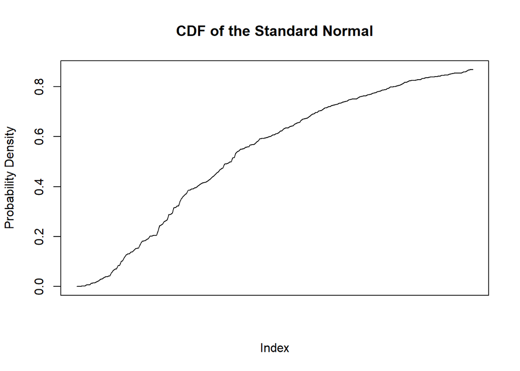

```r
a <- plot(pvalues,
     xaxt = "n",
     type = "l",
     main = "CDF of the Standard Normal",
     ylab="Probability Density")
```

Finally, we plot the probability density function.

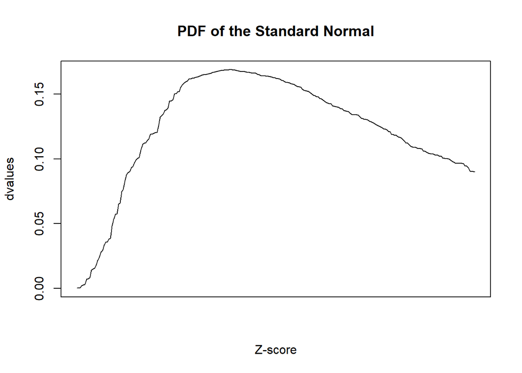

```r
dvalues <- dnorm(best_players$`Efficiency Rating`, mean=avg, sd=std)
b <- plot(dvalues, # Plot where y = values and x = index of the value in the vector
     xaxt = "n", # Don't label the x-axis
     type = "l", # Make it a line plot
     main = "PDF of the Standard Normal",
     xlab= "Z-score")
```

As we can see from the pdf plot, there is a definite rightward skew. This is because in our sample, there exists less variation amongst the lower ranked players. This can be seen in the Top Player’s Efficiency ratings plot. There exists bigger gaps in ratings between the top 20 or so and the rest of the sample.